# Análisis Exploratorio del Dataset Breast Cancer Biopsy

Daniel Alejandro Desposorio Vicente

# Análisis Exploratorio del Dataset Breast Cancer Biopsy

### Daniel Alejandro

Curso de R

# Introducción

## Objetivo

Analizar un conjunto de datos de biopsias de cáncer de mama mediante R, empleando:

- Manipulación de datos con **dplyr**
- Visualización con **ggplot2**
- Análisis exploratorio de datos

# Descripción del dataset

## Breast Cancer Biopsy

- 699 pacientes
- Datos obtenidos de biopsias de mama.
- Variables con valores entre **1 y 10**.
- Diagnóstico final:
  - **Benign**
  - **Malignant**

Principales variables:

- V1: Clump Thickness
- V2: Uniformity of Cell Size
- V3: Uniformity of Cell Shape
- …
- Class: Diagnóstico

# Pregunta 1

## ¿Cuál es la distribución de pacientes según el diagnóstico?

Se realizó un conteo de los pacientes clasificados como:

- Benign
- Malignant

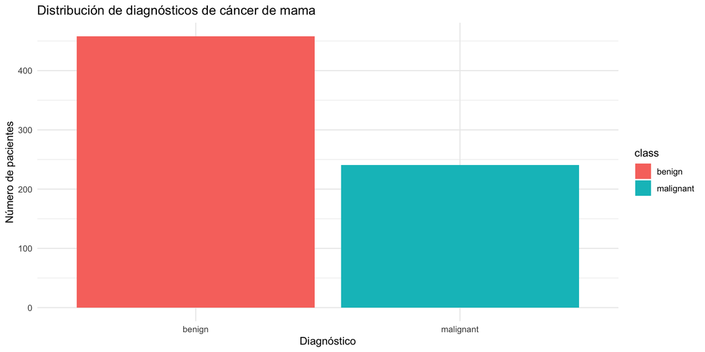

### Resultado

Predominan los casos benignos sobre los malignos.

# Pregunta 2

## ¿Existe diferencia en V1 entre tumores benignos y malignos?

**Variable analizada**

- V1 (Clump Thickness)

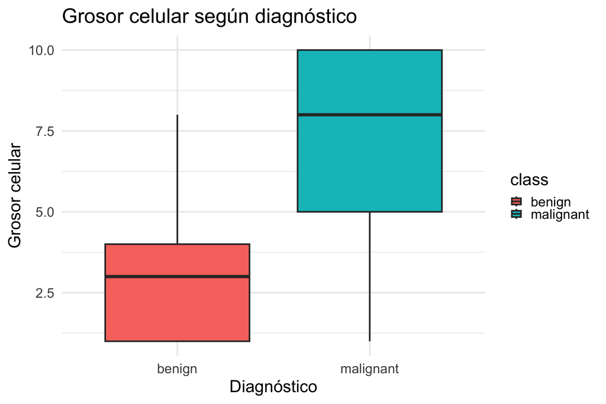

Boxplot comparando ambos grupos.

### Resultado

Los tumores malignos presentan valores de V1 considerablemente mayores que los benignos.

# Pregunta 3

## ¿Existe relación entre V1 y V2?

Se evaluó la relación entre:

- V1: Clump Thickness
- V2: Uniformity of Cell Size

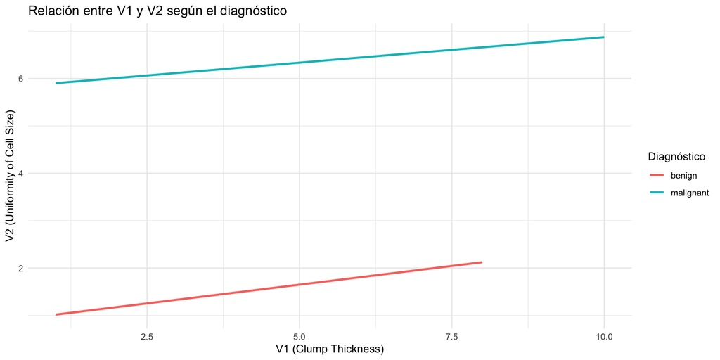

### Resultado

Existe una relación positiva entre ambas variables y los tumores malignos presentan valores más elevados.

# Conclusiones

- El análisis exploratorio permitió identificar diferencias claras entre tumores benignos y malignos.
- Los tumores malignos presentan mayores valores en variables relacionadas con alteraciones celulares.
- R y ggplot2 facilitan el análisis y la visualización de datos biomédicos.